# Análisis del Dataset: House Prices - Ames, Iowa

### 9.3.2 Relación GrLivArea vs log(SalePrice): estructura de agrupación

Antes de ajustar el GLMM conviene visualizar si la relación entre la superficie habitable y el precio varía entre barrios. Esto equivale a lo que haríamos con los datos de `sleepstudy`: primero sin agrupar, luego agrupando por individuo (aquí, por barrio).

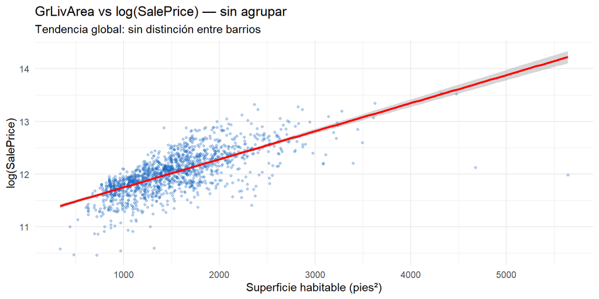

```r
# Diagrama de dispersión sin agrupar por barrio
ggplot(datos_glmm, aes(x = GrLivArea, y = logSalePrice)) +
  geom_point(alpha = 0.3, color = "#1565C0", size = 0.9) +
  geom_smooth(method = "lm", color = "red", se = TRUE) +
  labs(
    title    = "GrLivArea vs log(SalePrice) — sin agrupar",
    subtitle = "Tendencia global: sin distinción entre barrios",
    x        = "Superficie habitable (pies²)",
    y        = "log(SalePrice)"
  ) +
  theme_minimal()
```

> Sin tener en cuenta el barrio, la relación parece lineal y positiva. Sin embargo, esta visión **oculta la heterogeneidad entre grupos**: viviendas con la misma superficie pueden valer muy distinto según el barrio.

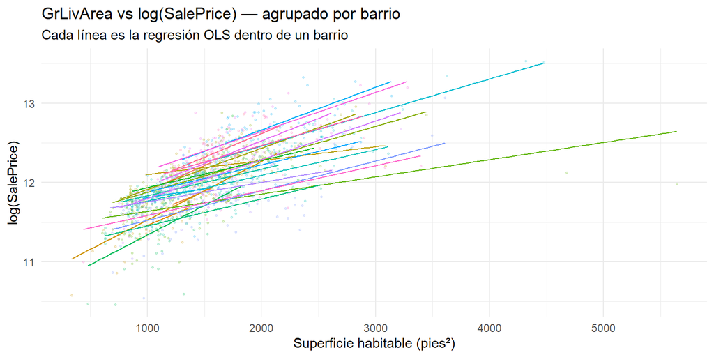

```r
# Diagrama de dispersión agrupado: una línea de regresión por barrio
ggplot(datos_glmm, aes(x = GrLivArea, y = logSalePrice,
                        group = Neighborhood, color = Neighborhood)) +
  geom_point(alpha = 0.2, size = 0.6) +
  geom_smooth(method = "lm", se = FALSE, linewidth = 0.5) +
  labs(
    title    = "GrLivArea vs log(SalePrice) — agrupado por barrio",
    subtitle = "Cada línea es la regresión OLS dentro de un barrio",
    x        = "Superficie habitable (pies²)",
    y        = "log(SalePrice)"
  ) +
  theme_minimal() +
  theme(legend.position = "none")
```

> Las líneas **no son paralelas** ni parten del mismo nivel: cada barrio tiene su propio intercepto (precio base) y, en algunos casos, su propia pendiente. Esto motiva el uso de efectos aleatorios.

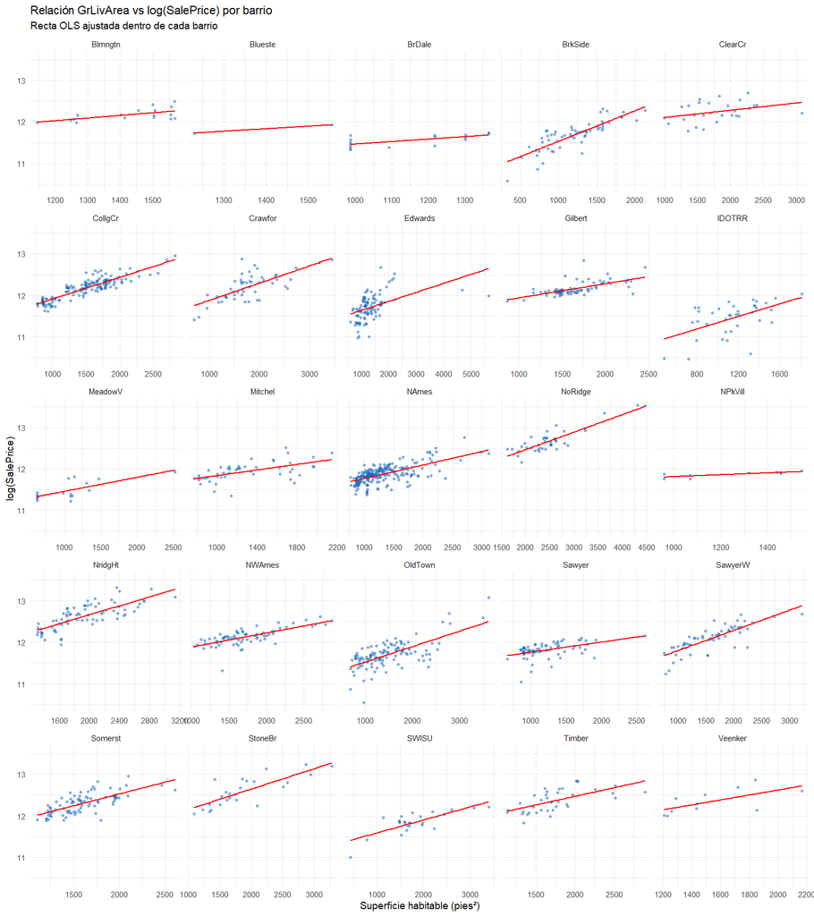

```r
# Panel individual por barrio (equivalente a facet_wrap(~ Subject) en sleepstudy)
ggplot(datos_glmm, aes(x = GrLivArea, y = logSalePrice)) +
  geom_point(alpha = 0.45, size = 0.7, color = "#1565C0") +
  geom_smooth(method = "lm", se = FALSE, color = "red", linewidth = 0.5) +
  facet_wrap(~ Neighborhood, scales = "free_x") +
  labs(
    title    = "Relación GrLivArea vs log(SalePrice) por barrio",
    subtitle = "Recta OLS ajustada dentro de cada barrio",
    x        = "Superficie habitable (pies²)",
    y        = "log(SalePrice)"
  ) +
  theme_minimal(base_size = 7)
```

> El panel confirma que tanto la **pendiente** (efecto de la superficie) como el **nivel base** del precio varían entre barrios. Los barrios con pocas viviendas (rectas inestables) se benefician especialmente del *pooling* parcial que ofrece el modelo mixto.

### 9.3.3 Modelo 1 — Intercepto aleatorio

Cada barrio tiene su propio nivel base de precio, pero la pendiente de los predictores es la misma para todos.

```r
glmm_int <- lmer(
  logSalePrice ~ GrLivArea + TotalBsmtSF + GarageArea +
                 OverallQual + YearBuilt + TotRmsAbvGrd +
                 (1 | Neighborhood),
  data = datos_glmm,
  REML = TRUE
)
summary(glmm_int)
```

```
## Linear mixed model fit by REML. t-tests use Satterthwaite's method [
## lmerModLmerTest]
## Formula: logSalePrice ~ GrLivArea + TotalBsmtSF + GarageArea + OverallQual +
##     YearBuilt + TotRmsAbvGrd + (1 | Neighborhood)
##    Data: datos_glmm
##
## REML criterion at convergence: -1052.1
##
## Scaled residuals:
##      Min       1Q   Median       3Q      Max
## -12.3200  -0.4326   0.0702   0.5287   3.1835
##
## Random effects:
##  Groups       Name        Variance Std.Dev.
##  Neighborhood (Intercept) 0.01353  0.1163
##  Residual                 0.02535  0.1592
## Number of obs: 1460, groups:  Neighborhood, 25
##
## Fixed effects:
##               Estimate Std. Error        df t value Pr(>|t|)
## (Intercept)  6.966e+00  5.899e-01 1.138e+03  11.810  < 2e-16 ***
## GrLivArea    1.983e-04  1.785e-05 1.445e+03  11.108  < 2e-16 ***
## TotalBsmtSF  9.301e-05  1.268e-05 1.440e+03   7.334 3.72e-13 ***
## GarageArea   2.382e-04  2.657e-05 1.437e+03   8.964  < 2e-16 ***
## OverallQual  9.606e-02  5.287e-03 1.451e+03  18.170  < 2e-16 ***
## YearBuilt    1.975e-03  3.018e-04 1.174e+03   6.545 8.87e-11 ***
## TotRmsAbvGrd 9.745e-03  4.783e-03 1.437e+03   2.037   0.0418 *
## ---
## Signif. codes:  0 '***' 0.001 '**' 0.01 '*' 0.05 '.' 0.1 ' ' 1
##
## Correlation of Fixed Effects:
##             (Intr) GrLvAr TtlBSF GargAr OvrllQ YerBlt
## GrLivArea   -0.051
## TotalBsmtSF  0.119 -0.226
## GarageArea   0.147 -0.171 -0.145
## OverallQual  0.189 -0.294 -0.182 -0.085
## YearBuilt   -0.998  0.069 -0.124 -0.152 -0.225
## TtRmsAbvGrd -0.095 -0.767  0.133  0.019  0.045  0.071
```

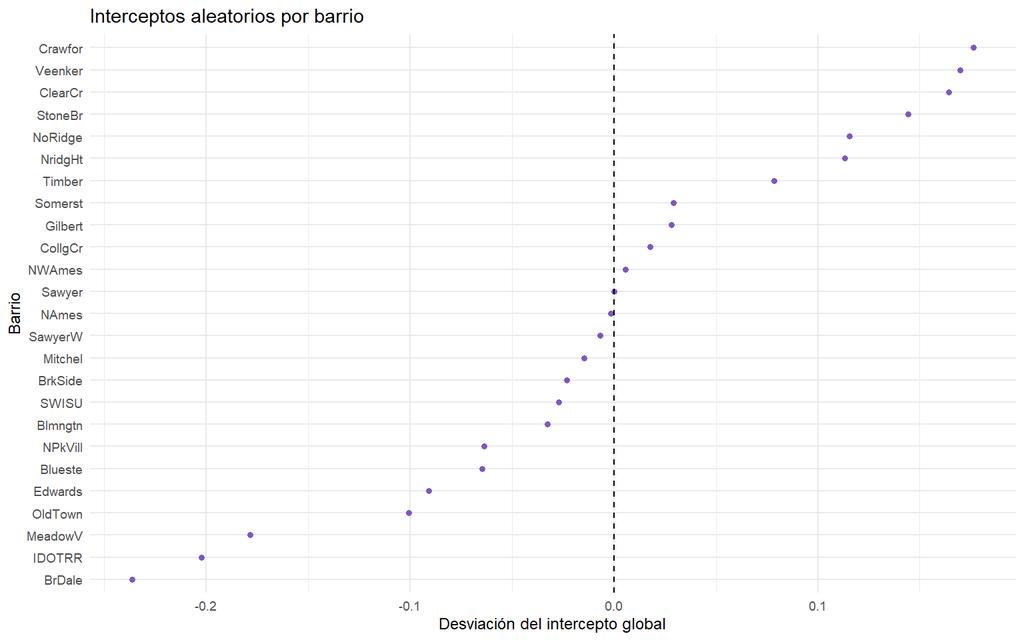

```r
# Interceptos aleatorios por barrio
ranef_int <- ranef(glmm_int)$Neighborhood
ranef_int$Neighborhood <- rownames(ranef_int)

ggplot(ranef_int, aes(x = reorder(Neighborhood, `(Intercept)`),
                       y = `(Intercept)`)) +
  geom_point(color = "#7E57C2") +
  geom_hline(yintercept = 0, linetype = "dashed") +
  coord_flip() +
  labs(title  = "Interceptos aleatorios por barrio",
       x = "Barrio", y = "Desviación del intercepto global") +
  theme_minimal(base_size = 9)
```

### 9.3.4 Trayectorias individuales — Modelo 1 (intercepto aleatorio)

Con `ggpredict(..., type = "random")` visualizamos cómo el modelo predice para un subconjunto de barrios representativos: las rectas deben ser **paralelas** (misma pendiente para todos) pero partir de **distintos niveles**, reflejando el intercepto aleatorio.

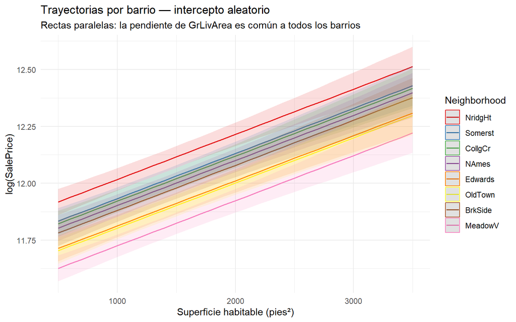

```r
# Seleccionamos 8 barrios representativos (variedad alta/media/baja)
barrios_sel <- c("NridgHt", "Somerst", "CollgCr", "NAmes",
                 "Edwards", "OldTown", "BrkSide", "MeadowV")

pred_int_traj <- ggpredict(
  glmm_int,
  terms     = c("GrLivArea [500:3500 by=100]",
                paste0("Neighborhood [", paste(barrios_sel, collapse = ", "), "]")),
  type      = "random"
)

plot(pred_int_traj) +
  labs(
    title    = "Trayectorias por barrio — intercepto aleatorio",
    subtitle = "Rectas paralelas: la pendiente de GrLivArea es común a todos los barrios",
    y        = "log(SalePrice)",
    x        = "Superficie habitable (pies²)"
  ) +
  theme_minimal()
```

> Las rectas **paralelas** son la firma del modelo de intercepto aleatorio: todos los barrios comparten la misma sensibilidad al tamaño de la vivienda, pero cada uno parte de un precio base distinto. Barrios como `NridgHt` tienen un intercepto muy alto (zona exclusiva) mientras que `MeadowV` se sitúa muy por debajo del promedio global.

### 9.3.5 Modelo 2 — Intercepto y pendiente aleatoria (GrLivArea)

Ahora también la relación entre superficie habitable y precio puede variar entre barrios.

```r
glmm_pen <- lmer(
  logSalePrice ~ GrLivArea + TotalBsmtSF + GarageArea +
                 OverallQual + YearBuilt + TotRmsAbvGrd +
                 (1 + GrLivArea | Neighborhood),
  data    = datos_glmm,
  REML    = TRUE,
  control = lmerControl(optimizer = "bobyqa",
                        optCtrl   = list(maxfun = 1e5))
)
summary(glmm_pen)
```

```
## Linear mixed model fit by REML. t-tests use Satterthwaite's method [
## lmerModLmerTest]
## Formula: logSalePrice ~ GrLivArea + TotalBsmtSF + GarageArea + OverallQual +
##     YearBuilt + TotRmsAbvGrd + (1 + GrLivArea | Neighborhood)
##    Data: datos_glmm
## Control: lmerControl(optimizer = "bobyqa", optCtrl = list(maxfun = 1e+05))
##
## REML criterion at convergence: -1248.2
##
## Scaled residuals:
##     Min      1Q  Median      3Q     Max
## -6.2496 -0.4833  0.0455  0.5383  5.2135
##
## Random effects:
##  Groups       Name        Variance  Std.Dev.  Corr
##  Neighborhood (Intercept) 4.352e-02 0.2086110
##               GrLivArea   1.929e-08 0.0001389 -0.91
##  Residual                 2.157e-02 0.1468694
## Number of obs: 1460, groups:  Neighborhood, 25
##
## Fixed effects:
##                Estimate Std. Error         df t value Pr(>|t|)
## (Intercept)   5.984e+00  5.631e-01  7.967e+02  10.627  < 2e-16 ***
## GrLivArea     2.966e-04  3.512e-05  2.906e+01   8.446 2.58e-09 ***
## TotalBsmtSF   1.281e-04  1.203e-05  1.434e+03  10.651  < 2e-16 ***
## GarageArea    2.315e-04  2.489e-05  1.431e+03   9.300  < 2e-16 ***
## OverallQual   9.063e-02  4.985e-03  1.443e+03  18.178  < 2e-16 ***
## YearBuilt     2.434e-03  2.880e-04  8.206e+02   8.453  < 2e-16 ***
## TotRmsAbvGrd -1.143e-03  4.595e-03  1.437e+03  -0.249    0.804
## ---
## Signif. codes:  0 '***' 0.001 '**' 0.01 '*' 0.05 '.' 0.1 ' ' 1
##
## Correlation of Fixed Effects:
##             (Intr) GrLvAr TtlBSF GargAr OvrllQ YerBlt
## GrLivArea   -0.083
## TotalBsmtSF  0.094 -0.084
## GarageArea   0.149 -0.089 -0.147
## OverallQual  0.213 -0.129 -0.190 -0.064
## YearBuilt   -0.995  0.027 -0.099 -0.155 -0.250
## TtRmsAbvGrd -0.080 -0.401  0.095  0.040  0.049  0.059
## optimizer (bobyqa) convergence code: 0 (OK)
## Model failed to converge with max|grad| = 0.591793 (tol = 0.002, component 1)
##   See ?lme4::convergence and ?lme4::troubleshooting.
## Model is nearly unidentifiable: very large eigenvalue
##  - Rescale variables?
## Model is nearly unidentifiable: large eigenvalue ratio
##  - Rescale variables?
```

### 9.3.6 Trayectorias individuales — Modelo 2 (intercepto + pendiente aleatoria)

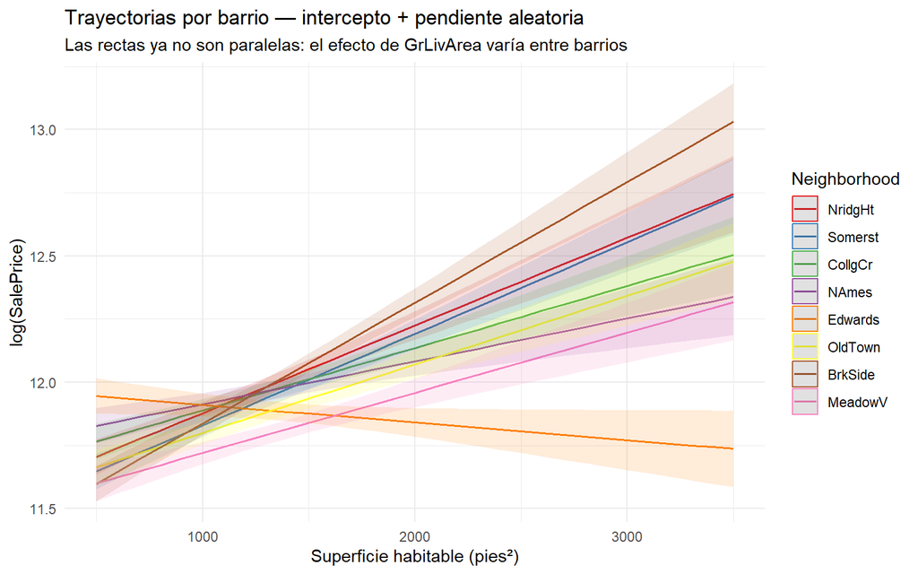

```r
pred_pen_traj <- ggpredict(
  glmm_pen,
  terms     = c("GrLivArea [500:3500 by=100]",
                paste0("Neighborhood [", paste(barrios_sel, collapse = ", "), "]")),
  type      = "random"
)

plot(pred_pen_traj) +
  labs(
    title    = "Trayectorias por barrio — intercepto + pendiente aleatoria",
    subtitle = "Las rectas ya no son paralelas: el efecto de GrLivArea varía entre barrios",
    y        = "log(SalePrice)",
    x        = "Superficie habitable (pies²)"
  ) +
  theme_minimal()
```

### 9.3.7 Efecto fijo de GrLivArea (Modelo 2)

El efecto fijo representa la estimación **promedio** del efecto de `GrLivArea` sobre `log(SalePrice)` una vez integrados todos los efectos aleatorios por barrio.

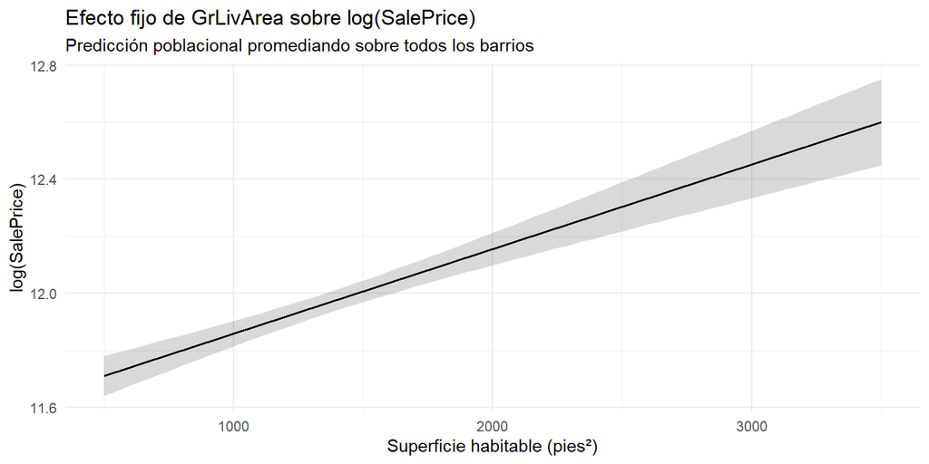

```r
eff_grliv <- ggpredict(glmm_pen, terms = "GrLivArea [500:3500 by=50]")

plot(eff_grliv) +
  labs(
    title    = "Efecto fijo de GrLivArea sobre log(SalePrice)",
    subtitle = "Predicción poblacional promediando sobre todos los barrios",
    y        = "log(SalePrice)",
    x        = "Superficie habitable (pies²)"
  ) +
  theme_minimal()
```

> Este gráfico equivale al efecto fijo de `Days` en el modelo `sleepstudy`: muestra la tendencia central del mercado. A mayor superficie, mayor precio estimado. La banda de confianza refleja la incertidumbre de esa estimación promedio (sin tener en cuenta los efectos aleatorios).

```r
# Test de razón de verosimilitudes (REML=FALSE para comparar)
glmm_int2 <- update(glmm_int, REML = FALSE)
glmm_pen2 <- update(glmm_pen, REML = FALSE)
lrt        <- anova(glmm_int2, glmm_pen2)
print(lrt)
```

```
## Data: datos_glmm
## Models:
## glmm_int2: logSalePrice ~ GrLivArea + TotalBsmtSF + GarageArea + OverallQual + YearBuilt + TotRmsAbvGrd + (1 | Neighborhood)
## glmm_pen2: logSalePrice ~ GrLivArea + TotalBsmtSF + GarageArea + OverallQual + YearBuilt + TotRmsAbvGrd + (1 + GrLivArea | Neighborhood)
##           npar     AIC     BIC logLik -2*log(L)  Chisq Df Pr(>Chisq)
## glmm_int2    9 -1133.1 -1085.6 575.57   -1151.1
## glmm_pen2   11 -1323.7 -1265.5 672.85   -1345.7 194.56  2  < 2.2e-16 ***
## ---
## Signif. codes:  0 '***' 0.001 '**' 0.01 '*' 0.05 '.' 0.1 ' ' 1
```

```r
# Tabla resumen
glmm_tabla <- data.frame(
  Modelo    = c("Intercepto aleatorio", "Intercepto + pendiente aleatoria"),
  AIC       = round(c(AIC(glmm_int2), AIC(glmm_pen2)), 1),
  BIC       = round(c(BIC(glmm_int2), BIC(glmm_pen2)), 1),
  LogLik    = round(c(logLik(glmm_int2), logLik(glmm_pen2)), 2),
  RMSE      = round(c(
    sqrt(mean(residuals(glmm_int)^2)),
    sqrt(mean(residuals(glmm_pen)^2))
  ), 5)
)
knitr::kable(glmm_tabla, caption = "Comparativa de modelos mixtos")
```

Comparativa de modelos mixtos

| Modelo | AIC | BIC | LogLik | RMSE |
| --- | --- | --- | --- | --- |
| Intercepto aleatorio | -1133.1 | -1085.6 | 575.57 | 0.15761 |
| Intercepto + pendiente aleatoria | -1323.7 | -1265.5 | 672.85 | 0.14451 |

> **Diferencia entre los dos modelos:**
> - **Intercepto aleatorio** `(1 | Neighborhood)`: cada barrio tiene un precio base distinto, pero el efecto de la superficie habitable es igual en todos los barrios. Es el modelo más parsimonioso.
> - **Intercepto + pendiente aleatoria** `(1 + GrLivArea | Neighborhood)`: tanto el precio base como el efecto de la superficie varían por barrio. Un m² adicional puede valer más en un barrio exclusivo que en uno modesto.

> Si el test LRT es significativo (p < 0,05) y el AIC del segundo modelo es menor, la pendiente aleatoria está justificada y el modelo con pendiente e intercepto aleatorios describe mejor la realidad del mercado inmobiliario.

### 9.3.8 Comparativa global de todos los modelos

```r
rmse_glmm_int <- sqrt(mean(residuals(glmm_int)^2))
rmse_glmm_pen <- sqrt(mean(residuals(glmm_pen)^2))

comp_global <- data.frame(
  Modelo = c(
    "LM log (Sesión 5)",
    sprintf("Penalizado (α=%.2f)", alpha_opt),
    "GAM",
    "GLMM — intercepto aleatorio",
    "GLMM — intercepto + pendiente"
  ),
  RMSE = round(c(rmse_lm, rmse_pen, rmse_gam,
                  rmse_glmm_int, rmse_glmm_pen), 5),
  AIC  = round(c(AIC(modelo_log), NA, AIC(modelo_gam),
                  AIC(glmm_int2), AIC(glmm_pen2)), 1)
)
knitr::kable(comp_global,
             caption = "Comparativa global — todos los modelos del trabajo",
             na.string = "—")
```

Comparativa global — todos los modelos del trabajo

| Modelo | RMSE | AIC |
| --- | --- | --- |
| LM log (Sesión 5) | 0.17468 | -935.6 |
| Penalizado (α=0.00) | 0.17524 | NA |
| GAM | 0.15352 | -1266.0 |
| GLMM — intercepto aleatorio | 0.15761 | -1133.1 |
| GLMM — intercepto + pendiente | 0.14451 | -1323.7 |

## 9.4 Conclusiones de la Sesión 7

- **Modelos penalizados:** La validación cruzada sobre `alpha` y `lambda` permite seleccionar automáticamente el equilibrio entre Ridge y Lasso. Con predictores correlacionados (habitual en datos de viviendas), Elastic Net suele superar a Lasso puro. Los coeficientes llevados a cero indican variables redundantes.
- **GAM:** Los grados de libertad efectivos (EDF) revelan qué predictores tienen una relación no lineal con `log(SalePrice)`. Un EDF alto en `GrLivArea` o `OverallQual` indica que la relación precio-superficie no es proporcional en toda la escala, algo que el LM no capturaba.
- **GLMMs:** Las viviendas no son completamente independientes: el barrio introduce correlación intragrupo. El intercepto aleatorio absorbe el nivel de precios de cada zona; añadir pendiente aleatoria permite que el efecto de la superficie varíe entre barrios. Si el LRT confirma la mejora, el GLMM con pendiente aleatoria es el modelo más completo y realista del trabajo.

*Análisis realizado con R 4.5.1 y los paquetes `tidyverse`, `ggplot2`, `car`, `corrplot`, `lmtest`, `boot`, `pROC`, `glmnet`, `mgcv`, `lme4`, `lmerTest`.*